# Practical 1

## Goals

- Parsing and working with CSV, TSV and JSON files
- Querying external data sources
- Data analyses

### Exercises

1. Installation and setting up of pip, scikit-learn and jupyter
2. Parsing and reading CSV/TSV files
3. Parsing and reading JSON files
4. Querying external data sources (Query endpoints and API)
5. Performing classical data analyses

## Screenshots

Screenshots have been provided so that you can check and compare whether the output you have is the same as what we want from the step (or exercise) in question.

## Exercise 1

##### Installation

Run the following commands on your **virtual machines**

**pip**

For installing `pip`, you need to run the following commands on your terminal:

**Note**: Please note that all the lines starting with `$` need to be run on the terminal.

`$ sudo apt update`

`$ sudo apt install python3-dev`

`$ sudo apt install python3-pip`

Installation of virtualenv

`$ sudo apt install virtualenv`

Installation inside virtualenv

`$ virtualenv --system-site-packages -p python3 env`

`$ source env/bin/activate`

Installation of jupyter

`$ python3 -m pip install --upgrade --force-reinstall --no-cache jupyter`

Installation of scikit-learn

`$ python3 -m pip install scikit-learn`

Installation of numpy

`$ python3 -m pip install numpy`

Installation of pandas

`$ python3 -m pip install pandas`

Installation of matplotlib

`$ python3 -m pip install matplotlib`

#### Hello World!

If your installation is successful, you can run the following command to clone the repository

`$ git clone https://github.com/johnsamuelwrites/DataMining`

`$ cd DataMining`

Run Jupyter Notebook (or Lab)

`$ jupyter notebook`

or

`$ jupyter lab`

A new page will appear on your browser and you will see the following image

[figure not shown]

Click on the tab 'Running'. You see no notebooks running (if it's the first time you are running jupyter).

[figure not shown]

Go back to the 'Files' tab and click on New and choose Python3 under Notebook

[figure not shown]

A new tab will open as shown below. Write the following code in the cell

```python
print("Hello World!")
```

```
Hello World!
```

[figure not shown]

You can go to any cell and press 'Run'

By default, your Notebook is named 'Untitled'. You can rename it as shown below, by clicking on the name 'Untitled' and by giving a new name.

[figure not shown]

Now go back to the 'Files' tab and you can see the renamed notebook. You can click on your notebook at any time to continue working.

[figure not shown]

Now let's continue working on your current Notebook. Write the following code to check whether scikit is properly installed.

The code below shows the available datasets from scikit.

```python
from sklearn import datasets

print(datasets.__all__)
```

```
['clear_data_home', 'dump_svmlight_file', 'fetch_20newsgroups', 'fetch_20newsgroups_vectorized', 'fetch_lfw_pairs', 'fetch_lfw_people', 'fetch_olivetti_faces', 'fetch_species_distributions', 'fetch_california_housing', 'fetch_covtype', 'fetch_rcv1', 'fetch_kddcup99', 'fetch_openml', 'get_data_home',…
```

[figure not shown]

Now, you are ready to go!!

**Note:**, You can stop Jupyter notebook at any point by typing "Ctrl+c" on the terminal and by pressing 'y' to confirm shutdown.

Practise the (optional) exercises given in practicals 0.

## Exercise 2

Most of the time, we work with CSV (comma-separated values) files for data analysis. A CSV file consits of one or more lines and each line has one or more values separated by commas. One can consider every line as a row and every value in a row as a column value. The first row is sometimes used to describe the column names.

Copy the file pl.csv to your current working directory (where you are running Jupyter: TP1) and use the following code to parse the csv file. Note the column names and datatypes (U100, i4), where U100 corresponds to 100-character unicode string and i4 corresponds to 32-bit signed integer.

Please check the complete list of dtypes [here](https://numpy.org/doc/stable/reference/arrays.dtypes.html).

```python
import numpy as np

dataset = np.loadtxt(
    "../../data/pl.csv",  # Change this value to the path of your CSV file
    dtype={"names": ("name", "year"), "formats": ("U100", "i4")},
    skiprows=1,  # skip the first row, since it's the header
    delimiter=",",  # the separator is comma since it is a CSV file
    encoding="UTF-8",  # UTF-8 encoding
)
print(dataset)
```

```
[('ENIAC coding system', 1943) ('ENIAC Short Code', 1946)
 ('Von Neumann and Goldstine graphing system', 1946)
 ('ARC Assembly', 1947) ('Plankalkül', 1948) ('CPC Coding scheme', 1948)
 ('Curry notation system', 1948) ('Short Code', 1949)
 ('assembly language', 1949) ('Short Code', 1950) ('G-code', 1950)
 ('Birkbeck Assembler', 1950) ('Superplan', 1951) ('ALGAE', 1951)
 ('Intermediate Programming Language', 1951)
 ('Regional Assembly Language', 1951)
 ('Boehm unnamed coding system', 1951) ('Klammerausdrücke', 1951)
 ('OMNIBAC Symbolic Assembler', 1951) ('Stanislaus', 1951)
 ('Whirlwind assembler', 1951) ('Rochester assembler', 1951)
 ('Sort Merge Generator', 1951) ('autocode', 1952) ('A-0 System', 1952)
 ('Editing Generator', 1952) ('COMPOOL', 1952) ('Speedcoding', 1953)
 ('READ/PRINT', 1953) ('Fortran', 1954) ('ARITH-MATIC', 1954)
 ('autocode', 1954) ('Laning and Zierler system', 1954)
 ('MATH-MATIC', 1954) ('MATRIX MATH', 1954) ('FLOW-MATIC', 1955)
 ('PACT', 1955) ('BACAIC', 1955) ('Freiburger Code', 1955)
 ('Sequentielle Formelübersetzung', 1955) ('Internal Translator', 1955)
 ('PRINT', 1955) ('Information Processing Language', 1956)
 ('FORTRAN for the IBM 704', 1956) ('Fortran', 1957) ('COMTRAN', 1957)
 ('GEORGE', 1957) ('UNICODE', 1957) ('ALGOL 58', 1958) ('Lisp', 1958)
 ('ALGOL', 1958) ('FORTRAN III', 1958) ('FORTRAN II', 1958)
 ('JOVIAL', 1959) ('TRAC', 1959) ('COBOL', 1959) ('MAD', 1959)
 ('Lisp', 1959) ('FACT', 1959) ('COBOL', 1960) ('ALCOR', 1960)
 ('ALGOL 60', 1960) ('FORTRAN IV', 1961) ('TECO', 1962) ('SNOBOL', 1962)
 ('APL', 1962) ('Simula', 1962) ('CORC', 1962) ('CPL', 1963)
 ('JOSS', 1963) ('P′′', 1964) ('Report Program Generator', 1964)
 ('TRAC', 1964) ('BASIC', 1964) ('COWSEL', 1964) ('MARK IV', 1964)
 ('MIMIC', 1964) ('PL/I', 1964) ('Speakeasy', 1964) ('IBM RPG II', 1965)
 ('Atlas Autocode', 1965) ('TELCOMP', 1965) ('Euler', 1966)
 ('ISWIM', 1966) ('ALGOL W', 1966)
 ('Massachusetts General Hospital Utility Multi-Programming System', 1966)
 ('JOSS', 1966) ('Coral 66', 1966) ('BCPL', 1966) ('APL', 1966)
 ('FORTRAN 66', 1966)
 ('Massachusetts General Hospital Utility Multi-Programming System', 1967)
 ('Hop', 1967) ('XPL', 1967) ('Interlisp', 1967) ('BCPL', 1967)
 ('Simula', 1967) ('Space Programming Language', 1967) ('PILOT', 1968)
 ('ALGOL 68', 1968)]
```

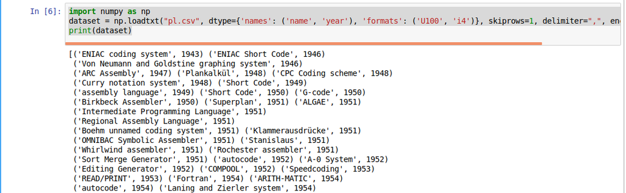

[CSV support in numpy](https://docs.scipy.org/doc/numpy/reference/generated/numpy.loadtxt.html) (**Ref:** (https://docs.scipy.org/doc/numpy/reference/generated/numpy.loadtxt.html)) is different from Python's default [CSV reader](https://docs.python.org/3.9/library/csv.html) (**Ref:** (https://docs.python.org/3.9/library/csv.html)) because of its capability to support the [data types](https://docs.scipy.org/doc/numpy/reference/arrays.dtypes.html) (**Ref:** (https://docs.scipy.org/doc/numpy/reference/arrays.dtypes.html)). Before continuing, take a deep look at [numpy.loadtxt](https://docs.scipy.org/doc/numpy/reference/generated/numpy.loadtxt.html) (**Ref:** (https://docs.scipy.org/doc/numpy/reference/generated/numpy.loadtxt.html)).

Copy the file pl.tsv to your current working directory and use the following code to parse the tsv file.

```python
import numpy as np

dataset = np.loadtxt(
    "../../data/pl.tsv",  # Change this value to the path of your CSV file
    dtype={"names": ("name", "year"), "formats": ("U100", "i4")},
    skiprows=1,
    delimiter="\t",
    encoding="UTF-8",
)
print(dataset)
```

```
[('ENIAC coding system', 1943) ('ENIAC Short Code', 1946)
 ('Von Neumann and Goldstine graphing system', 1946)
 ('ARC Assembly', 1947) ('Plankalkül', 1948) ('CPC Coding scheme', 1948)
 ('Curry notation system', 1948) ('Short Code', 1949)
 ('assembly language', 1949) ('Short Code', 1950)
 ('Birkbeck Assembler', 1950) ('G-code', 1950) ('Superplan', 1951)
 ('ALGAE', 1951) ('Intermediate Programming Language', 1951)
 ('Regional Assembly Language', 1951)
 ('Boehm unnamed coding system', 1951) ('Klammerausdrücke', 1951)
 ('OMNIBAC Symbolic Assembler', 1951) ('Stanislaus', 1951)
 ('Whirlwind assembler', 1951) ('Rochester assembler', 1951)
 ('Sort Merge Generator', 1951) ('Editing Generator', 1952)
 ('COMPOOL', 1952) ('autocode', 1952) ('A-0 System', 1952)
 ('READ/PRINT', 1953) ('Speedcoding', 1953) ('Fortran', 1954)
 ('MATRIX MATH', 1954) ('autocode', 1954) ('ARITH-MATIC', 1954)
 ('Laning and Zierler system', 1954) ('MATH-MATIC', 1954)
 ('FLOW-MATIC', 1955) ('BACAIC', 1955) ('Freiburger Code', 1955)
 ('Sequentielle Formelübersetzung', 1955) ('Internal Translator', 1955)
 ('PRINT', 1955) ('PACT', 1955) ('Information Processing Language', 1956)
 ('FORTRAN for the IBM 704', 1956) ('Fortran', 1957) ('UNICODE', 1957)
 ('COMTRAN', 1957) ('GEORGE', 1957) ('ALGOL 58', 1958) ('Lisp', 1958)
 ('FORTRAN III', 1958) ('FORTRAN II', 1958) ('ALGOL', 1958)
 ('JOVIAL', 1959) ('TRAC', 1959) ('COBOL', 1959) ('Lisp', 1959)
 ('MAD', 1959) ('FACT', 1959) ('COBOL', 1960) ('COBOL', 1960)
 ('ALGOL 60', 1960) ('ALCOR', 1960) ('FORTRAN IV', 1961) ('SNOBOL', 1962)
 ('TECO', 1962) ('Simula', 1962) ('APL', 1962) ('CORC', 1962)
 ('CPL', 1963) ('JOSS', 1963) ('P′′', 1964)
 ('Report Program Generator', 1964) ('TRAC', 1964) ('BASIC', 1964)
 ('COWSEL', 1964) ('PL/I', 1964) ('MARK IV', 1964) ('MIMIC', 1964)
 ('Speakeasy', 1964) ('IBM RPG II', 1965) ('Atlas Autocode', 1965)
 ('TELCOMP', 1965) ('Euler', 1966) ('ISWIM', 1966) ('ALGOL W', 1966)
 ('JOSS', 1966)
 ('Massachusetts General Hospital Utility Multi-Programming System', 1966)
 ('BCPL', 1966) ('Coral 66', 1966) ('FORTRAN 66', 1966) ('APL', 1966)
 ('Hop', 1967)
 ('Massachusetts General Hospital Utility Multi-Programming System', 1967)
 ('Space Programming Language', 1967) ('BCPL', 1967) ('Interlisp', 1967)
 ('Simula', 1967) ('XPL', 1967) ('PILOT', 1968)]
```

Note the changes in the above code compared to the previous one. A TSV file is a tab-separated file, i.e., the column values are separated by a tab ((\t)).

For counting the number of rows in your dataset, you can use `len()`

```python
print(len(dataset))
```

```
100
```

You can also display the output of variables and methods in a notebook without `print()`

```python
len(dataset)
```

```
100
```

## Exercise 3

Most of the external data sources may provide their data in JSON format. Our next exercise is to parse JSON files. Copy the file pl.json to your current working directory and use the following code to parse the JSON file. In this exercise, we use [Pandas python package](https://pandas.pydata.org/pandas-docs/stable/) (**Ref:** (https://pandas.pydata.org/pandas-docs/stable/)) to parse the JSON file to obtain a [Pandas DataFrame](https://pandas.pydata.org/pandas-docs/stable/generated/pandas.DataFrame.html) (**Ref:** (https://pandas.pydata.org/pandas-docs/stable/generated/pandas.DataFrame.html)). Try using methods like transpose (**Ref:** (https://pandas.pydata.org/pandas-docs/stable/generated/pandas.DataFrame.transpose.html#pandas.DataFrame.transpose)), count (**Ref:** (https://pandas.pydata.org/pandas-docs/stable/generated/pandas.DataFrame.count.html#pandas.DataFrame.count)) etc.

Before continuing this exercise, please practice working with Pandas. Take a look at [10 minutes to pandas](https://pandas.pydata.org/pandas-docs/stable/getting_started/10min.html) (**Ref:** (https://pandas.pydata.org/pandas-docs/stable/getting_started/10min.html)).

```python
from pandas import json_normalize
import pandas as pd
import json

data = json.load(open("../../data/pl.json"))
dataframe = json_normalize(data)
print(dataframe)
```

```
                                languageLabel  year
0                         ENIAC coding system  1943
1                            ENIAC Short Code  1946
2   Von Neumann and Goldstine graphing system  1946
3                                ARC Assembly  1947
4                                  Plankalkül  1948
..                                        ...   ...
95                                       BCPL  1967
96                                  Interlisp  1967
97                                     Simula  1967
98                                        XPL  1967
99                                      PILOT  1968

[100 rows x 2 columns]
```

And the output without `print()`

```python
dataframe
```

|  | languageLabel | year |
| --- | --- | --- |
| 0 | ENIAC coding system | 1943 |
| 1 | ENIAC Short Code | 1946 |
| 2 | Von Neumann and Goldstine graphing system | 1946 |
| 3 | ARC Assembly | 1947 |
| 4 | Plankalkül | 1948 |
| ... | ... | ... |
| 95 | BCPL | 1967 |
| 96 | Interlisp | 1967 |
| 97 | Simula | 1967 |
| 98 | XPL | 1967 |
| 99 | PILOT | 1968 |

100 rows × 2 columns

To display the values of the column **year**:

```python
dataframe["year"]
```

```
0     1943
1     1946
2     1946
3     1947
4     1948
      ...
95    1967
96    1967
97    1967
98    1967
99    1968
Name: year, Length: 100, dtype: object
```

To display the values of the column **languageLabel**:

```python
dataframe["languageLabel"]
```

```
0                           ENIAC coding system
1                              ENIAC Short Code
2     Von Neumann and Goldstine graphing system
3                                  ARC Assembly
4                                    Plankalkül
                        ...
95                                         BCPL
96                                    Interlisp
97                                       Simula
98                                          XPL
99                                        PILOT
Name: languageLabel, Length: 100, dtype: object
```

```python
dataframe.describe()
```

|  | languageLabel | year |
| --- | --- | --- |
| count | 100 | 100 |
| unique | 88 | 24 |
| top | COBOL | 1951 |
| freq | 3 | 11 |

To display the unique values of the column **year**:

```python
dataframe["year"].unique()
```

```
array(['1943', '1946', '1947', '1948', '1949', '1950', '1951', '1952',
       '1953', '1954', '1955', '1956', '1957', '1958', '1959', '1960',
       '1961', '1962', '1963', '1964', '1965', '1966', '1967', '1968'],
      dtype=object)
```

To display the unique values of the column **languageLabel**:

```python
dataframe["languageLabel"].unique()
```

```
array(['ENIAC coding system', 'ENIAC Short Code',
       'Von Neumann and Goldstine graphing system', 'ARC Assembly',
       'Plankalkül', 'CPC Coding scheme', 'Curry notation system',
       'Short Code', 'assembly language', 'Birkbeck Assembler', 'G-code',
       'Superplan', 'ALGAE', 'Intermediate Programming Language',
       'Regional Assembly Language', 'Boehm unnamed coding system',
       'Klammerausdrücke', 'OMNIBAC Symbolic Assembler', 'Stanislaus',
       'Whirlwind assembler', 'Rochester assembler',
       'Sort Merge Generator', 'Editing Generator', 'COMPOOL', 'autocode',
       'A-0 System', 'READ/PRINT', 'Speedcoding', 'Fortran',
       'MATRIX MATH', 'ARITH-MATIC', 'Laning and Zierler system',
       'MATH-MATIC', 'FLOW-MATIC', 'BACAIC', 'Freiburger Code',
       'Sequentielle Formelübersetzung', 'Internal Translator', 'PRINT',
       'PACT', 'Information Processing Language',
       'FORTRAN for the IBM 704', 'UNICODE', 'COMTRAN', 'GEORGE',
       'ALGOL 58', 'Lisp', 'FORTRAN III', 'FORTRAN II', 'ALGOL', 'JOVIAL',
       'TRAC', 'COBOL', 'MAD', 'FACT', 'ALGOL 60', 'ALCOR', 'FORTRAN IV',
       'SNOBOL', 'TECO', 'Simula', 'APL', 'CORC', 'CPL', 'JOSS', 'P′′',
       'Report Program Generator', 'BASIC', 'COWSEL', 'PL/I', 'MARK IV',
       'MIMIC', 'Speakeasy', 'IBM RPG II', 'Atlas Autocode', 'TELCOMP',
       'Euler', 'ISWIM', 'ALGOL W',
       'Massachusetts General Hospital Utility Multi-Programming System',
       'BCPL', 'Coral 66', 'FORTRAN 66', 'Hop',
       'Space Programming Language', 'Interlisp', 'XPL', 'PILOT'],
      dtype=object)
```

To sort the values by one or more columns:

```python
dataframe.sort_values(["year"])
```

|  | languageLabel | year |
| --- | --- | --- |
| 0 | ENIAC coding system | 1943 |
| 1 | ENIAC Short Code | 1946 |
| 2 | Von Neumann and Goldstine graphing system | 1946 |
| 3 | ARC Assembly | 1947 |
| 4 | Plankalkül | 1948 |
| ... | ... | ... |
| 98 | XPL | 1967 |
| 93 | Massachusetts General Hospital Utility Multi-P... | 1967 |
| 92 | Hop | 1967 |
| 94 | Space Programming Language | 1967 |
| 99 | PILOT | 1968 |

100 rows × 2 columns

```python
dataframe.sort_values(["year", "languageLabel"])
```

|  | languageLabel | year |
| --- | --- | --- |
| 0 | ENIAC coding system | 1943 |
| 1 | ENIAC Short Code | 1946 |
| 2 | Von Neumann and Goldstine graphing system | 1946 |
| 3 | ARC Assembly | 1947 |
| 5 | CPC Coding scheme | 1948 |
| ... | ... | ... |
| 93 | Massachusetts General Hospital Utility Multi-P... | 1967 |
| 97 | Simula | 1967 |
| 94 | Space Programming Language | 1967 |
| 98 | XPL | 1967 |
| 99 | PILOT | 1968 |

100 rows × 2 columns

```python
dataframe.sort_values(["languageLabel"])
```

|  | languageLabel | year |
| --- | --- | --- |
| 26 | A-0 System | 1952 |
| 62 | ALCOR | 1960 |
| 13 | ALGAE | 1951 |
| 52 | ALGOL | 1958 |
| 48 | ALGOL 58 | 1958 |
| ... | ... | ... |
| 20 | Whirlwind assembler | 1951 |
| 98 | XPL | 1967 |
| 8 | assembly language | 1949 |
| 31 | autocode | 1954 |
| 25 | autocode | 1952 |

100 rows × 2 columns

To obtain the data types of the columns:

```python
dataframe.dtypes
```

```
languageLabel    object
year             object
dtype: object
```

## Exercise 4

[figure not shown]

```python
import urllib.request
import json
import pandas as pd

url = "https://query.wikidata.org/sparql?query=SELECT%20%3FlanguageLabel%20(YEAR(%3Finception)%20as%20%3Fyear)%0AWHERE%0A%7B%0A%20%20%23instances%20of%20programming%20language%0A%20%20%3Flanguage%20wdt%3AP31%20wd%3AQ9143%3B%0A%20%20%20%20%20%20%20%20%20%20%20%20wdt%3AP571%20%3Finception%3B%0A%20%20%20%20%20%20%20%20%20%20%20%20rdfs%3Alabel%20%3FlanguageLabel.%0A%20%20FILTER(lang(%3FlanguageLabel)%20%3D%20%22en%22)%0A%7D%0AORDER%20BY%20%3Fyear%0ALIMIT%20100&format=json"
response = urllib.request.urlopen(url)
responsedata = json.loads(response.read().decode("utf-8"))

array = []

for data in responsedata["results"]["bindings"]:
    array.append([data["year"]["value"], data["languageLabel"]["value"]])

dataframe = pd.DataFrame(array, columns=["year", "languageLabel"])
dataframe = dataframe.astype(dtype={"year": "<i4", "languageLabel": "<U200"})
print(dataframe)
```

```
    year                              languageLabel
0   1942                                 Plankalkül
1   1943                        ENIAC coding system
2   1946                           ENIAC Short Code
3   1946  Von Neumann and Goldstine graphing system
4   1947                               ARC Assembly
..   ...                                        ...
95  1967                                        XPL
96  1967                 Space Programming Language
97  1968                                      FOCAL
98  1968                                      PILOT
99  1968                                     MAPPER

[100 rows x 2 columns]
```

```python
dataframe
```

|  | year | languageLabel |
| --- | --- | --- |
| 0 | 1942 | Plankalkül |
| 1 | 1943 | ENIAC coding system |
| 2 | 1946 | ENIAC Short Code |
| 3 | 1946 | Von Neumann and Goldstine graphing system |
| 4 | 1947 | ARC Assembly |
| ... | ... | ... |
| 95 | 1967 | XPL |
| 96 | 1967 | Space Programming Language |
| 97 | 1968 | FOCAL |
| 98 | 1968 | PILOT |
| 99 | 1968 | MAPPER |

100 rows × 2 columns

```python
dataframe["year"].describe()
```

```
count     100.000000
mean     1958.280000
std         6.532096
min      1942.000000
25%      1952.750000
50%      1959.000000
75%      1964.000000
max      1968.000000
Name: year, dtype: float64
```

```python
dataframe["languageLabel"].describe()
```

```
count          100
unique          99
top       autocode
freq             2
Name: languageLabel, dtype: object
```

```python
dataframe.dtypes
```

```
year              int32
languageLabel    object
dtype: object
```

## Exercise 5

This exercise will use some basic data analyses. Continuing with the code in Exercise 1.4, le's count the number of programming languages released in a year.

```python
grouped = dataframe.groupby("year").count()
grouped
```

| year | languageLabel |
| --- | --- |
| 1942 | 1 |
| 1943 | 1 |
| 1946 | 2 |
| 1947 | 1 |
| 1948 | 2 |
| 1950 | 3 |
| 1951 | 11 |
| 1952 | 4 |
| 1953 | 2 |
| 1954 | 4 |
| 1955 | 8 |
| 1956 | 1 |
| 1957 | 6 |
| 1958 | 2 |
| 1959 | 4 |
| 1960 | 7 |
| 1961 | 1 |
| 1962 | 5 |
| 1963 | 3 |
| 1964 | 11 |
| 1965 | 5 |
| 1966 | 7 |
| 1967 | 6 |
| 1968 | 3 |

You can also use multiple aggregate functions using agg()

```python
grouped = dataframe.groupby("year").agg(["count"])
grouped
```

[output not shown]

Till now, we worked with tables having two columns. Now we focus on tables with three columns (programming language, year, paradigm). Copy the file plparadigm.json to your working directory. And test the following program.

```python
from pandas.io.json import json_normalize
import pandas as pd
import json

jsondata = json.load(open("../../data/plparadigm.json"))
array = []

for data in jsondata:
    array.append([data["year"], data["languageLabel"], data["paradigmLabel"]])

dataframe = pd.DataFrame(array, columns=["year", "languageLabel", "paradigmLabel"])
dataframe = dataframe.astype(
    dtype={"year": "int64", "languageLabel": "<U200", "paradigmLabel": "<U200"}
)
dataframe
```

|  | year | languageLabel | paradigmLabel |
| --- | --- | --- | --- |
| 0 | 1948 | Plankalkül | procedural programming |
| 1 | 1949 | assembly language | non-structured programming |
| 2 | 1949 | Short Code | procedural programming |
| 3 | 1950 | Short Code | procedural programming |
| 4 | 1953 | Speedcoding | procedural programming |
| ... | ... | ... | ... |
| 95 | 1970 | Pascal | imperative programming |
| 96 | 1970 | PLEX | procedural programming |
| 97 | 1970 | BLISS | structured programming |
| 98 | 1971 | A♯ | functional programming |
| 99 | 1971 | KRL | knowledge representation and reasoning |

100 rows × 3 columns

```python
grouped = dataframe.groupby(["year", "paradigmLabel"]).agg(["count"])
grouped
```

| year | paradigmLabel | languageLabel count |
| --- | --- | --- |
| 1948 | procedural programming | 1 |
| 1949 | non-structured programming | 1 |
|  | procedural programming | 1 |
| 1950 | procedural programming | 1 |
| 1953 | procedural programming | 1 |
| ... | ... | ... |
| 1970 | imperative programming | 1 |
|  | procedural programming | 1 |
|  | structured programming | 1 |
| 1971 | functional programming | 1 |
|  | knowledge representation and reasoning | 1 |

73 rows × 1 columns

Now test the following program. Compare the difference in output.

```python
grouped = dataframe.groupby(["paradigmLabel", "year"]).agg(["count"])
grouped
```

| paradigmLabel | year | languageLabel count |
| --- | --- | --- |
| array programming | 1954 | 1 |
|  | 1957 | 1 |
|  | 1962 | 1 |
|  | 1966 | 1 |
| assembly language | 1956 | 1 |
| ... | ... | ... |
| structured programming | 1957 | 1 |
|  | 1958 | 1 |
|  | 1962 | 1 |
|  | 1966 | 1 |
|  | 1970 | 1 |

73 rows × 1 columns

Your next goal is to run the following query to get the population information of different countries (limited to 10000 rows). Run the following query on [Wikidata query service](https://query.wikidata.org) and download the JSON file.

```
SELECT DISTINCT ?countryLabel (YEAR(?date) as ?year) ?population
WHERE {
 ?country wdt:P31 wd:Q6256; #Country
   p:P1082 ?populationStatement;
  rdfs:label ?countryLabel. #Label
 ?populationStatement ps:P1082 ?population; #population
  pq:P585 ?date. #period in time
 FILTER(lang(?countryLabel)="en") #Label in English
}
ORDER by ?countryLabel ?year
LIMIT 10000
```

`https://query.wikidata.org/sparql?query=%0ASELECT%20DISTINCT%20%3FcountryLabel%20(YEAR(%3Fdate)%20as%20%3Fyear)%20%3Fpopulation%0AWHERE%20%7B%0A%20%20%3Fcountry%20wdt%3AP31%20wd%3AQ6256%3B%20%23Country%20%0A%20%20%20%20p%3AP1082%20%3FpopulationStatement%3B%0A%20%20%20%20rdfs%3Alabel%20%3FcountryLabel.%20%23Label%0A%20%20%3FpopulationStatement%20ps%3AP1082%20%3Fpopulation%3B%20%23population%0A%20%20%20%20pq%3AP585%20%3Fdate.%20%23period%20in%20time%0A%20%20FILTER(lang(%3FcountryLabel)%3D%22en%22)%20%23Label%20in%20English%0A%7D%0AORDER%20by%20%3FcountryLabel%20%3Fyear%0ALIMIT%2010000&format=json`

Now, compute and display the following information (using various [operations available in pandas library](https://pandas.pydata.org/pandas-docs/stable/10min.html) (**Ref:** (https://pandas.pydata.org/pandas-docs/stable/10min.html))):

1. The population of countries in alphabetical order of their names and ascending order of year.
2. The latest available population of every country
3. The country with the lowest and highest population (considering the latest population)

```python
from pandas.io.json import json_normalize
import pandas as pd
import json

jsondata = json.load(open("../../data/q1.json"))
array = []

for data in jsondata:
    array.append([data["countryLabel"], data["year"], data["population"]])

dataframe = pd.DataFrame(array, columns=["countryLabel", "year", "population"])
dataframe = dataframe.astype(
    dtype={"countryLabel": "<U200", "year": "int64", "population": "int64"}
)
dataframe
```

|  | countryLabel | year | population |
| --- | --- | --- | --- |
| 0 | Afghanistan | 1960 | 8774440 |
| 1 | Afghanistan | 1961 | 8953544 |
| 2 | Afghanistan | 1962 | 9141783 |
| 3 | Afghanistan | 1963 | 9339507 |
| 4 | Afghanistan | 1964 | 9547131 |
| ... | ... | ... | ... |
| 8719 | Zimbabwe | 2010 | 13076978 |
| 8720 | Zimbabwe | 2011 | 13358738 |
| 8721 | Zimbabwe | 2012 | 13724317 |
| 8722 | Zimbabwe | 2013 | 14149648 |
| 8723 | Zimbabwe | 2022 | 15178979 |

8724 rows × 3 columns

```python
print("1. The population of countries in alphabetical order of their names and ascending order of year.")
grouped = dataframe.groupby(["countryLabel", "year"])[["population"]].sum()
grouped
```

```
1. The population of countries in alphabetical order of their names and ascending order of year.
```

| countryLabel | year | population |
| --- | --- | --- |
| Afghanistan | 1960 | 8774440 |
|  | 1961 | 8953544 |
|  | 1962 | 9141783 |
|  | 1963 | 9339507 |
|  | 1964 | 9547131 |
| ... | ... | ... |
| Zimbabwe | 2010 | 13076978 |
|  | 2011 | 13358738 |
|  | 2012 | 13724317 |
|  | 2013 | 14149648 |
|  | 2022 | 15178979 |

8484 rows × 1 columns

```python
print("2.  The latest available population of every country")
grouped = dataframe.groupby(["countryLabel"]).tail(1)

grouped
```

```
2.  The latest available population of every country
```

|  | countryLabel | year | population |
| --- | --- | --- | --- |
| 57 | Afghanistan | 2021 | 37466414 |
| 114 | Albania | 2022 | 2793592 |
| 171 | Algeria | 2020 | 43900000 |
| 230 | Andorra | 2021 | 78151 |
| 286 | Angola | 2020 | 32866270 |
| ... | ... | ... | ... |
| 8576 | Vietnam | 2019 | 96208984 |
| 8604 | Wales | 2016 | 3113000 |
| 8611 | Yemen | 2017 | 28250420 |
| 8668 | Zambia | 2017 | 17094130 |
| 8723 | Zimbabwe | 2022 | 15178979 |

190 rows × 3 columns

```python
print("3. The country with the lowest and highest population (considering the latest population)")


grouped = dataframe.groupby(["countryLabel"]).tail(1)[["countryLabel", "population"]].sort_values("population").iloc[[0, -1]]

grouped
```

```
3. The country with the lowest and highest population (considering the latest population)
```

|  | countryLabel | population |
| --- | --- | --- |
| 5624 | Niue | 1612 |
| 6097 | People's Republic of China | 1442965000 |

```
SELECT ?title ?subjectLabel ?year
{
  ?article wdt:P31 wd:Q13442814; #scientific article
           wdt:P1476 ?title; #title of the article
           wdt:P921 ?subject; #main subject
           wdt:P577 ?date. #publication date
  ?subject rdfs:label ?subjectLabel.
  BIND(YEAR(?date) as ?year).
  #published after 2010
  FILTER(lang(?title)="en" &&
     lang(?subjectLabel)="en" && ?year>2010)
}
LIMIT 10000
```

Now, compute and display the following information (using various [operations available in pandas library](https://pandas.pydata.org/pandas-docs/stable/10min.html) (**Ref:** (https://pandas.pydata.org/pandas-docs/stable/10min.html))):

1. The number of articles published on different subjects every year.
2. Top subject of interest to the scientific community every year(based on the above query results).
3. Top 10 subjects of interest to the scientific community (based on the above query results) since 2010.

**Hint**:Take a look at functions groupby, reset_index, head, tail, sort_values, count of Pandas

**Note**: If you get time-out errors, please change the LIMIT to some lower values (1000, 2000, 5000).

## Exercise 6

In our final exercise, we will query Wikidata and obtain the URLs of the images. Then we will download these images.

```python
%pip install sparqlwrapper
```

```python
import sys
from SPARQLWrapper import SPARQLWrapper, JSON

endpoint_url = "https://query.wikidata.org/sparql"

# Get cities
query = """SELECT DISTINCT ?grandeville ?grandevilleLabel ?pays ?paysLabel ?image {
  ?grandeville wdt:P31 wd:Q1549591;
               wdt:P17 ?pays;
               wdt:P18 ?image.
 SERVICE wikibase:label { bd:serviceParam wikibase:language "fr". }
}
LIMIT 10"""


def get_results(endpoint_url, query):
    user_agent = "WDQS-example Python/%s.%s" % (
        sys.version_info[0],
        sys.version_info[1],
    )
    sparql = SPARQLWrapper(endpoint_url, agent=user_agent)
    sparql.setQuery(query)
    sparql.setReturnFormat(JSON)
    return sparql.query().convert()


array = []
results = get_results(endpoint_url, query)

for result in results["results"]["bindings"]:
    array.append(
        (
            result["grandevilleLabel"]["value"],
            result["paysLabel"]["value"],
            result["image"]["value"],
        )
    )
```

```python
dataframe = pd.DataFrame(array, columns=["ville", "pays", "image"])
dataframe = dataframe.astype(
    dtype={"ville": "<U200", "pays": "<U200", "image": "<U200"}
)
dataframe
```

|  | ville | pays | image |
| --- | --- | --- | --- |
| 0 | Barquisimeto | Venezuela | http://commons.wikimedia.org/wiki/Special:FilePath/Baqtoeste.jpg |
| 1 | Winterthour | Suisse | http://commons.wikimedia.org/wiki/Special:FilePath/View%20of%20Winterthur.jpg |
| 2 | Siliguri | Inde | http://commons.wikimedia.org/wiki/Special:FilePath/Siliguri%20view.jpg |
| 3 | Boukhara | Ouzbékistan | http://commons.wikimedia.org/wiki/Special:FilePath/Kalon-Ensemble%20Buchara.jpg |
| 4 | Pokhara | Népal | http://commons.wikimedia.org/wiki/Special:FilePath/Pokhara1.JPG |
| 5 | Surate | Inde | http://commons.wikimedia.org/wiki/Special:FilePath/Surat%20at%20night.JPG |
| 6 | Brescia | Italie | http://commons.wikimedia.org/wiki/Special:FilePath/Brescia%20city%20skyline%20from%20the%20city%... |
| 7 | Khabarovsk | Russie | http://commons.wikimedia.org/wiki/Special:FilePath/%D0%A3%D1%81%D1%81%D1%83%D1%80%D0%B8%D0%B9%D1... |
| 8 | Kampala | Ouganda | http://commons.wikimedia.org/wiki/Special:FilePath/Kampalamontage.png |
| 9 | Bolzano | Italie | http://commons.wikimedia.org/wiki/Special:FilePath/TalferbrueckeBozenMeranBahn.jpg |

We will now download these images

```python
import requests
import shutil
import os
from IPython.display import Image, HTML

def path_to_image_html(path):
    return '<img width="500" src="'+ path + '"/>'

def download_image(url):

    headers = {"User-Agent": "Mozilla/5.0"}
    request = requests.get(url, allow_redirects=True, headers=headers, stream=True)
    if request.status_code == 200:
        with open(os.path.basename(url), "wb") as image:
            request.raw.decode_content = True
            shutil.copyfileobj(request.raw, image)
    return request.status_code

pd.set_option('display.max_colwidth', 100)
```

```python
HTML(dataframe.to_html(escape=False ,formatters=dict(image=path_to_image_html)))
```

|  | ville | pays | image |
| --- | --- | --- | --- |
| 0 | Barquisimeto | Venezuela |  |
| 1 | Winterthour | Suisse |  |
| 2 | Siliguri | Inde |  |
| 3 | Boukhara | Ouzbékistan |  |
| 4 | Pokhara | Népal |  |
| 5 | Surate | Inde |  |
| 6 | Brescia | Italie |  |
| 7 | Khabarovsk | Russie |  |
| 8 | Kampala | Ouganda |  |
| 9 | Bolzano | Italie |  |

Modify the above code and download images related to any subject of your choice (cities, historical monuments, flowers, buildings, etc.)

```python
import sys
from SPARQLWrapper import SPARQLWrapper, JSON

endpoint_url = "https://query.wikidata.org/sparql"

# Get cities
query = """SELECT DISTINCT ?planeLabel ?entry ?image {
  ?plane wdt:P31 wd:Q15056993;
               wdt:P729 ?entry;
               wdt:P729 ?retirement;
               wdt:P495 wd:Q30;
               wdt:P18 ?image.

  SERVICE wikibase:label { bd:serviceParam wikibase:language "fr". }
  FILTER (?retirement > "1939-01-01"^^xsd:dateTime && ?entry < "1945-12-31"^^xsd:dateTime)
}"""


def get_results(endpoint_url, query):
    user_agent = "WDQS-example Python/%s.%s" % (
        sys.version_info[0],
        sys.version_info[1],
    )
    sparql = SPARQLWrapper(endpoint_url, agent=user_agent)
    sparql.setQuery(query)
    sparql.setReturnFormat(JSON)
    return sparql.query().convert()


array = []
results = get_results(endpoint_url, query)

for result in results["results"]["bindings"]:
    array.append(
        (
            result["planeLabel"]["value"],
            result["entry"]["value"],
            result["image"]["value"],
        )
    )


dataframe = pd.DataFrame(array, columns=["planeLabel", "entry", "image"])
dataframe = dataframe.astype(
    dtype={"planeLabel": "<U200", "entry" : "<U200", "image": "<U200"}
)
srt = dataframe.sort_values("entry")

pd.set_option('display.max_colwidth', 100)

HTML(srt.to_html(escape=False ,formatters=dict(image=path_to_image_html)))
```

|  | planeLabel | entry | image |
| --- | --- | --- | --- |
| 15 | Brewster F2A Buffalo | 1939-04-01T00:00:00Z |  |
| 3 | Grumman F4F Wildcat | 1940-01-01T00:00:00Z |  |
| 18 | Grumman G-44 Widgeon | 1940-02-21T00:00:00Z |  |
| 9 | Boeing 307 | 1940-07-08T00:00:00Z |  |
| 1 | Consolidated PB2Y Coronado | 1940-12-01T00:00:00Z |  |
| 2 | Consolidated PB2Y Coronado | 1940-12-01T00:00:00Z |  |
| 12 | Bell P-39 Airacobra | 1941-01-01T00:00:00Z |  |
| 13 | Martin PBM Mariner | 1941-01-01T00:00:00Z |  |
| 24 | Consolidated B-24 Liberator | 1941-01-01T00:00:00Z |  |
| 25 | Lockheed Ventura | 1941-01-01T00:00:00Z |  |
| 8 | Martin B-26 Marauder | 1941-01-01T00:00:00Z |  |
| 11 | Brewster SB2A Buccaneer | 1942-01-01T00:00:00Z |  |
| 22 | North American P-51 Mustang | 1942-01-01T00:00:00Z |  |
| 14 | Grumman TBF Avenger | 1942-02-01T00:00:00Z |  |
| 5 | F4U Corsair | 1942-12-28T00:00:00Z |  |
| 10 | F6F Hellcat | 1943-01-01T00:00:00Z |  |
| 6 | Lockheed P-38 Lightning | 1943-01-01T00:00:00Z |  |
| 16 | Lockheed Constellation | 1943-01-01T00:00:00Z |  |
| 23 | Curtiss SB2C Helldiver | 1943-01-01T00:00:00Z |  |
| 7 | Boeing YB-40 Flying Fortress | 1943-05-29T00:00:00Z |  |
| 19 | P-61 Black Widow | 1944-01-01T00:00:00Z |  |
| 20 | Grumman F7F Tigercat | 1944-01-01T00:00:00Z |  |
| 17 | Boeing B-29 Superfortress | 1944-05-08T00:00:00Z |  |
| 0 | Martin JRM Mars | 1945-01-01T00:00:00Z |  |
| 4 | Lockheed F-80 Shooting Star | 1945-02-01T00:00:00Z |  |
| 21 | F8F Bearcat | 1945-05-21T00:00:00Z |  |